# Ordinal Analysis (Universe #3)

### Muthen & Muthen Aggregated plots

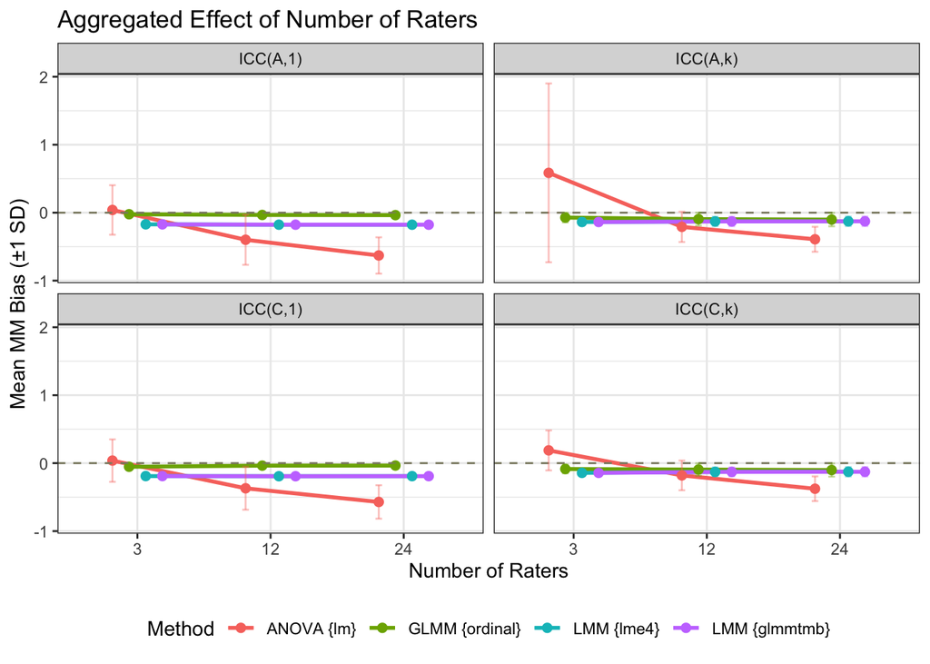

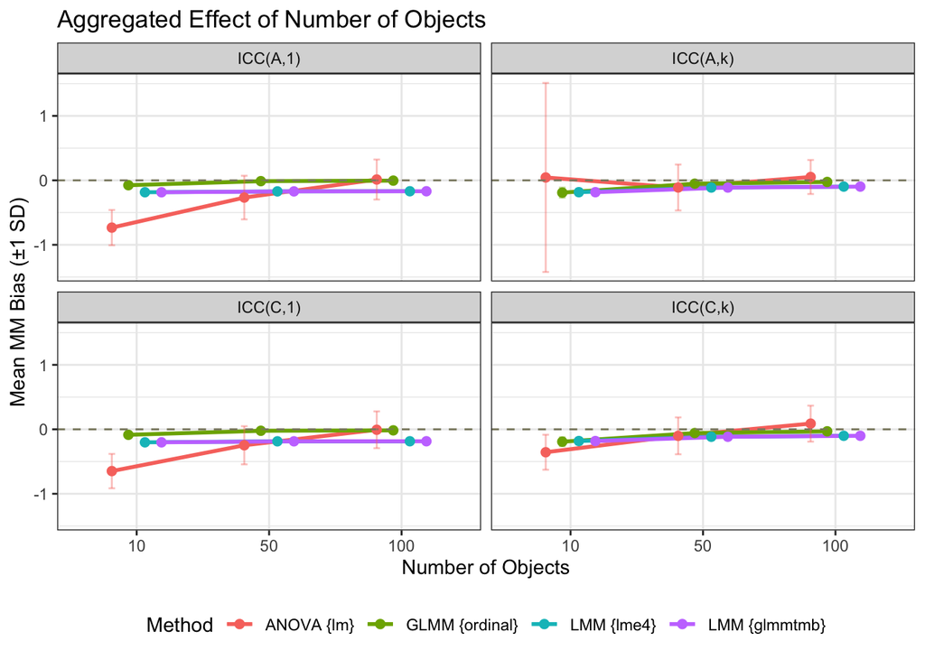

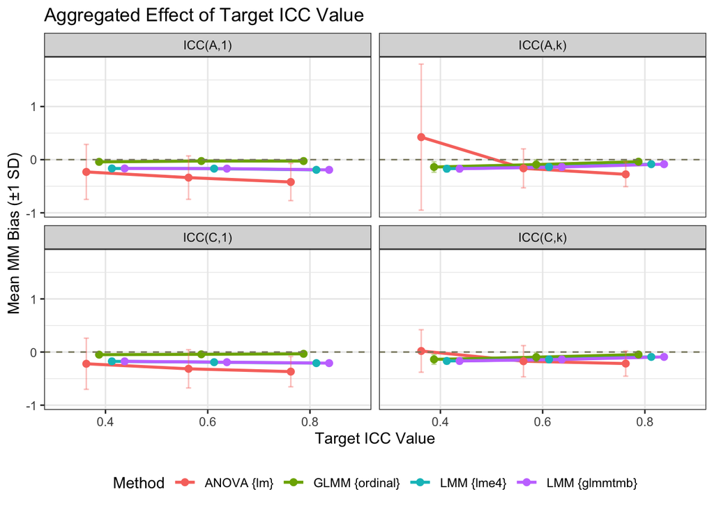

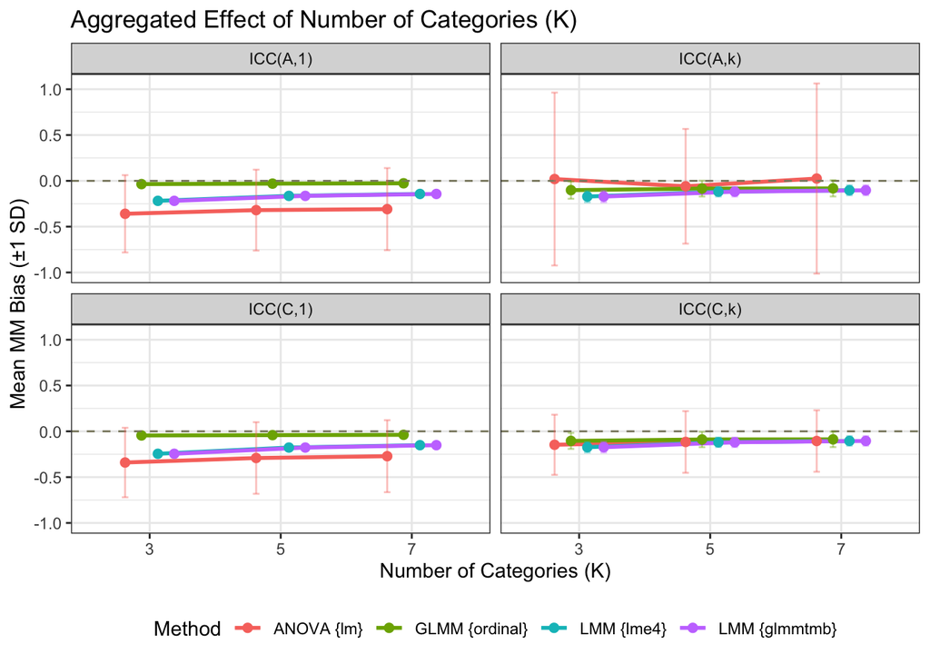

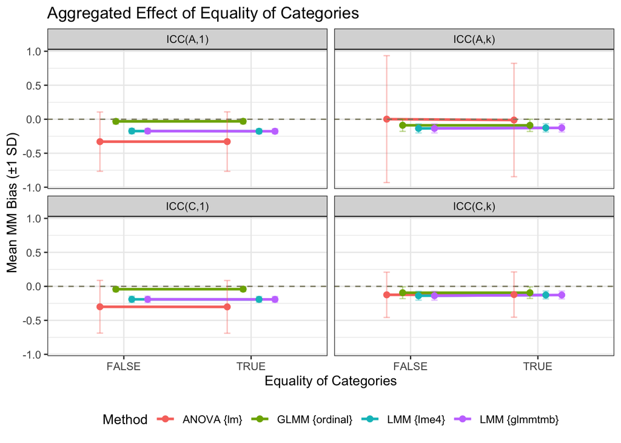

```r
 factors_to_test <- c("n_raters", "n_objects", "target_icc", "k_category", "e_category")

# # Generate a list of faceted plots
 mm_aggregate_plots <- map(set_names(factors_to_test),
 ~ {plot_aggregated_facet(bias, .x, bias2, 2)
 })

 mm_aggregate_plots
```

## 3.4 Root Mean Square Error (RMSE)

### RMSE Individual Plots

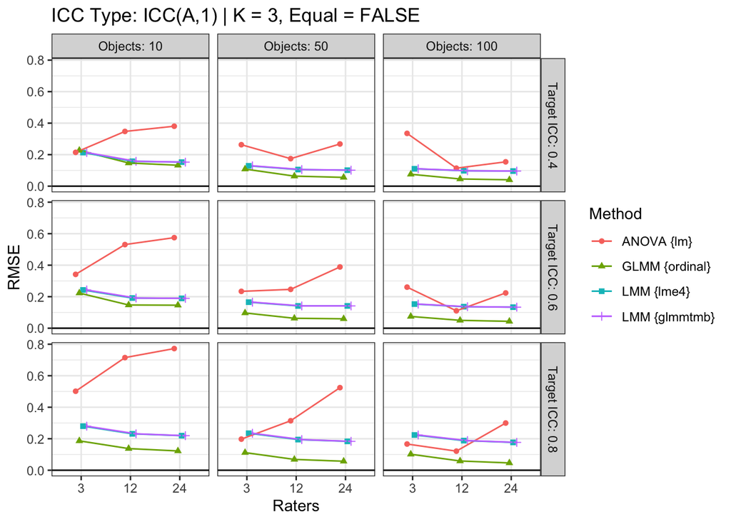

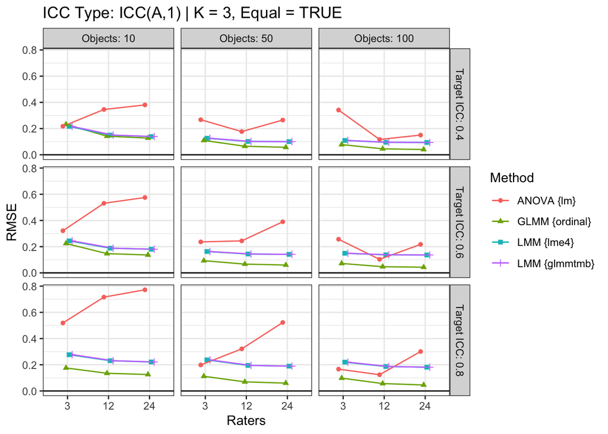

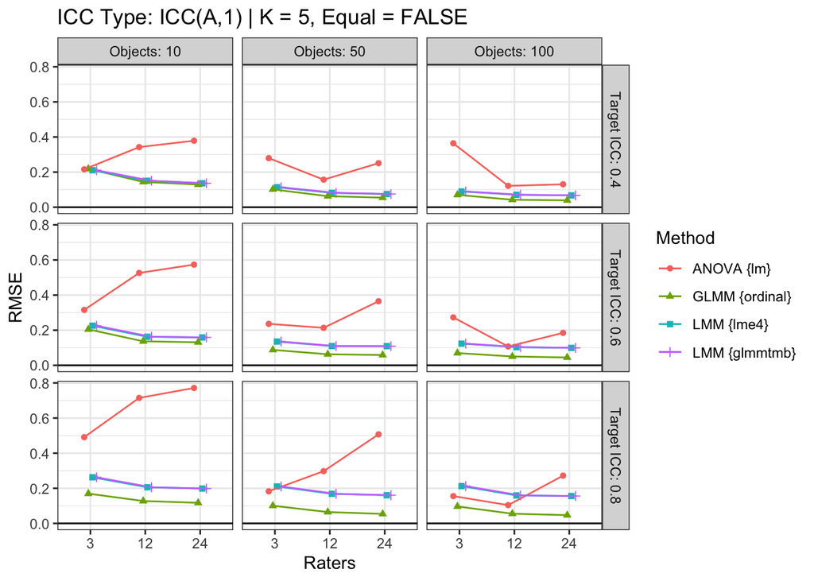

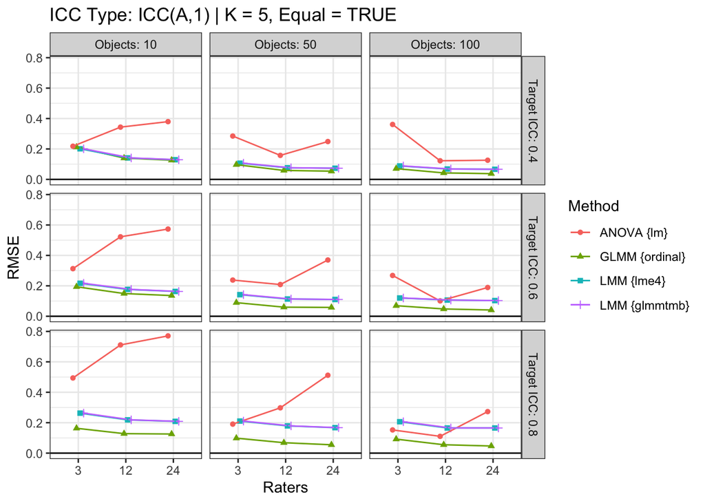

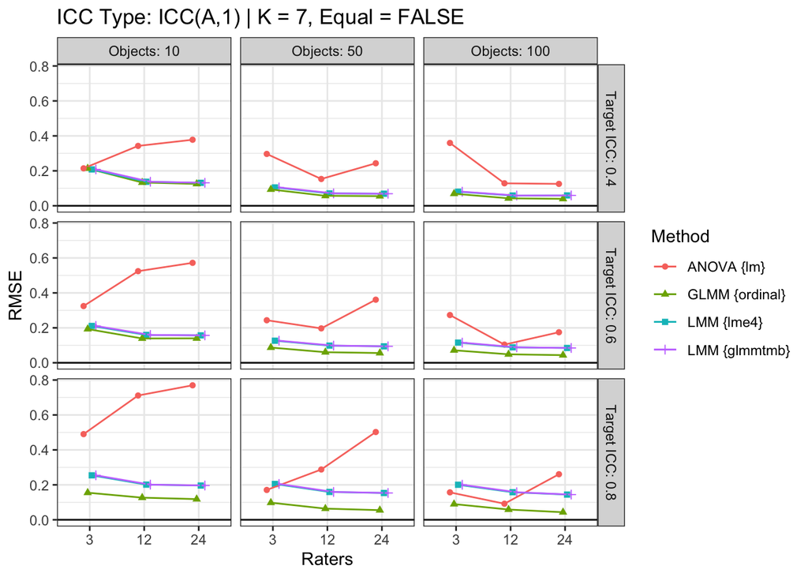

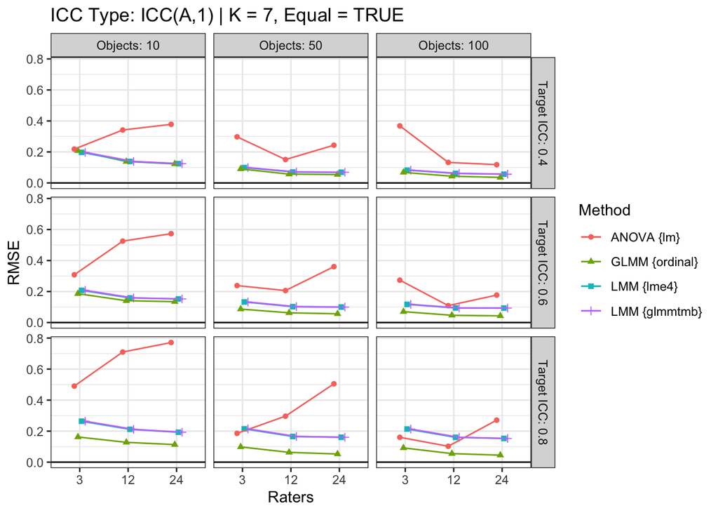

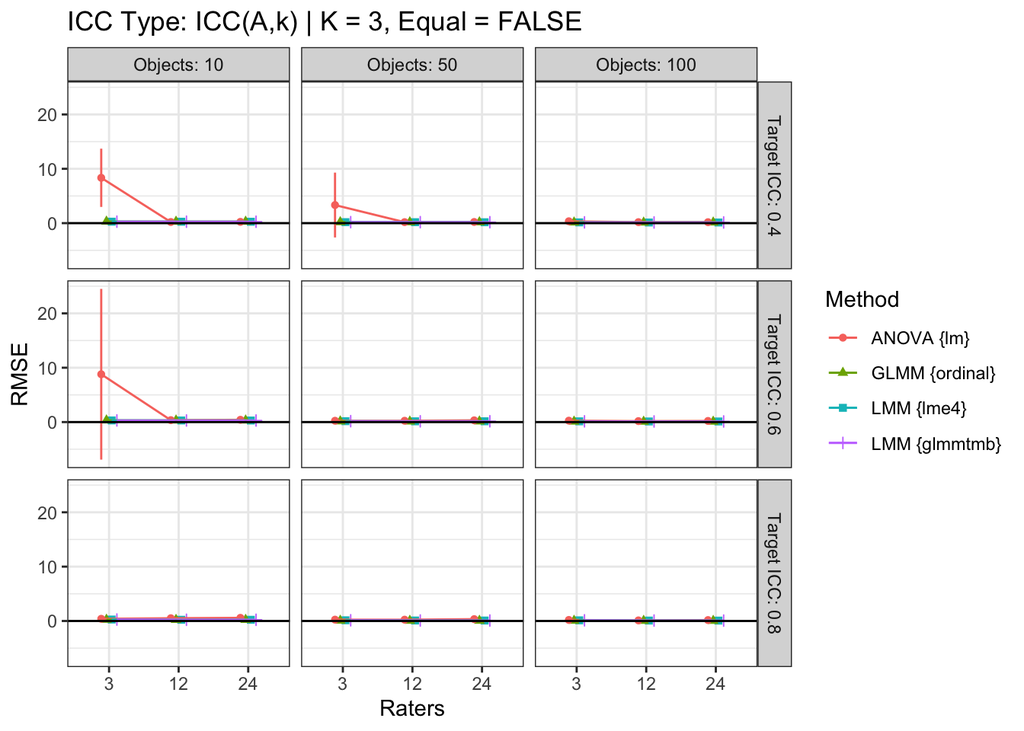

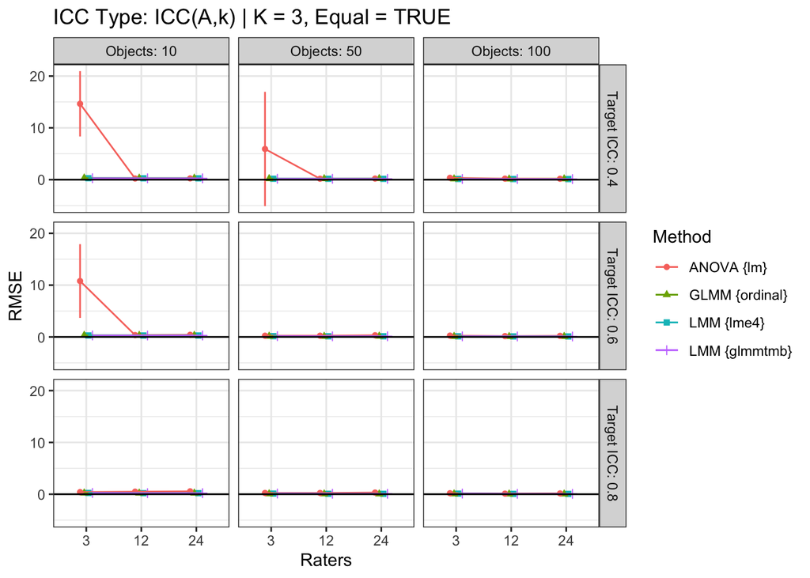

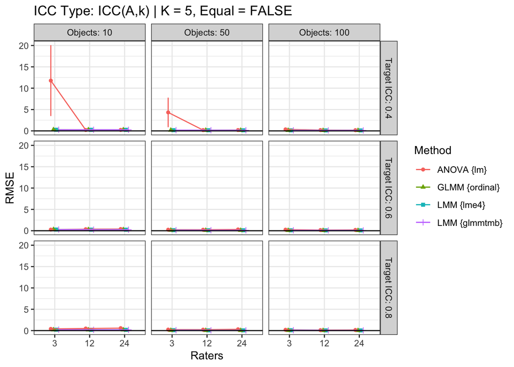

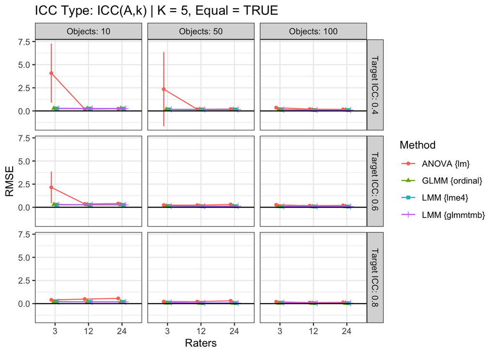

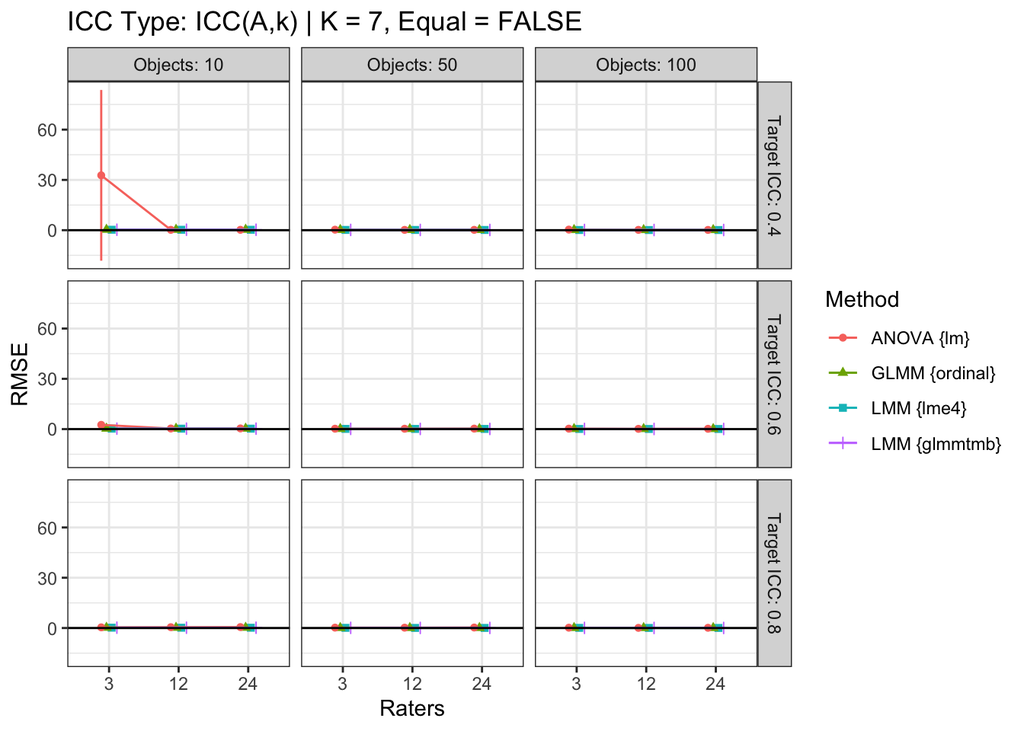

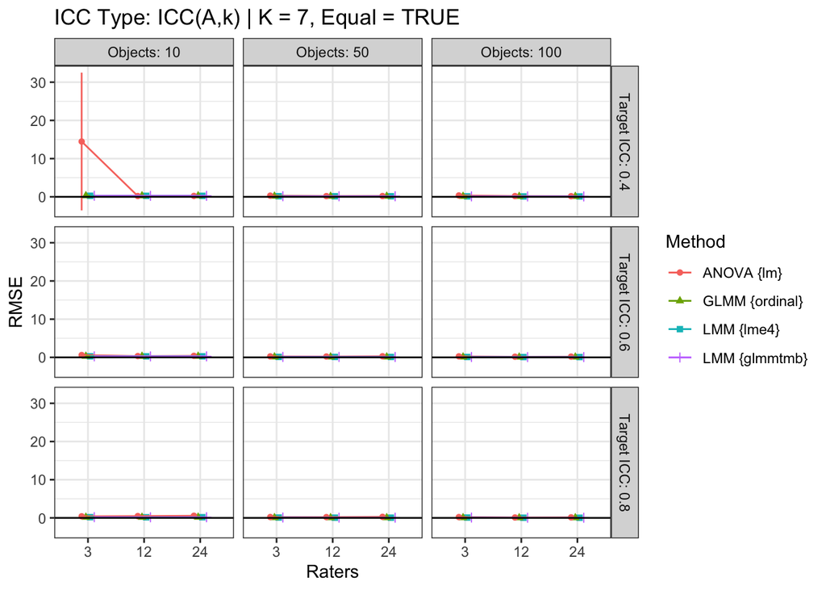

[12 more figures not shown]

```r
rmse_labs <- c(
  n_raters = "Raters",
  n_objects = "Objects",
  target_icc = "Target ICC",
  n_category = "Category",
  bias = "RMSE"
)

rmse_plots <- bias |>
  group_by(icc, k_category, e_category) |>
  group_split() |>
  # 2. Map over the split data
  map(~ {
    # Extract values for a dynamic and descriptive title
    icc_val <- unique(.x$icc)
    k_val   <- unique(.x$k_category)
    e_val   <- unique(.x$e_category)

    # Generate the plot using your generalized function
    plot_simulation_bias(
      data = .x,
      x_var = n_raters,
      y_var = rmse,
      col_var = Method,
      facet_row = `Target ICC`,
      facet_col = Objects,
      my_geoms = my_geom_rmse,
      plot_labs = rmse_labs,
      title = paste0("ICC Type: ", icc_val, " | K = ", k_val, ", Equal = ", e_val)
    )
  })


rmse_plots
```

### RMSE Aggregated plots

Aggregated RMSE plots

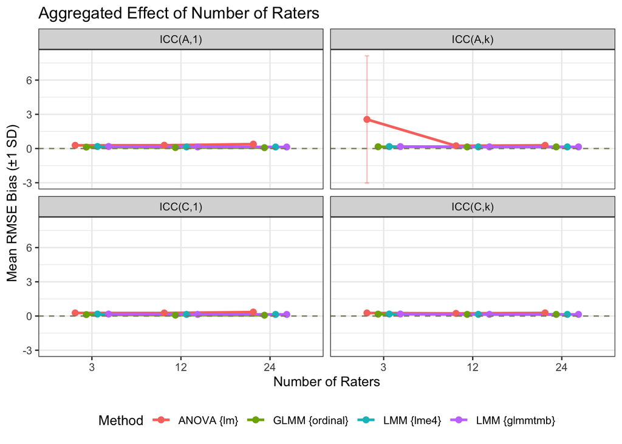

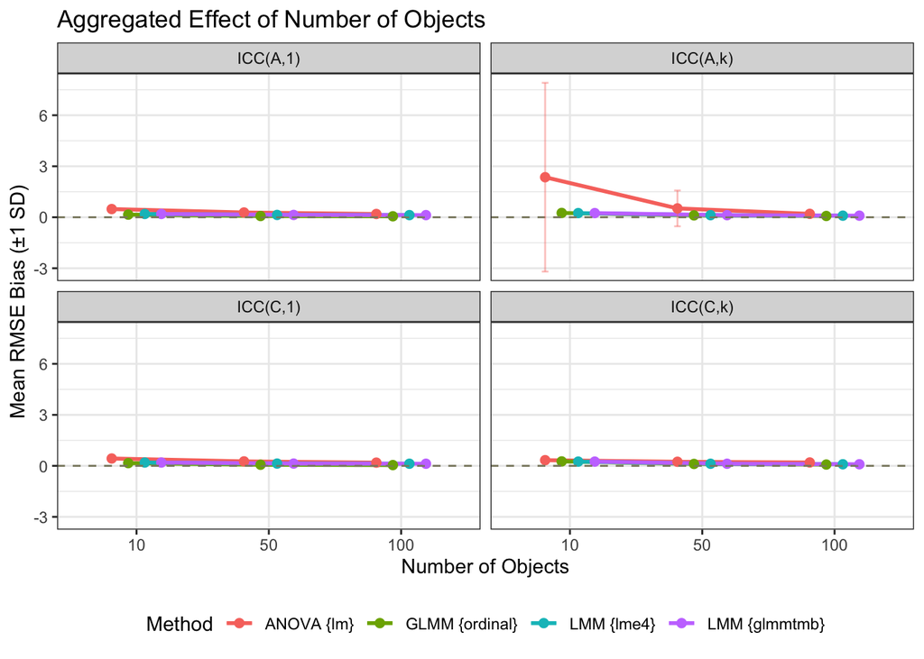

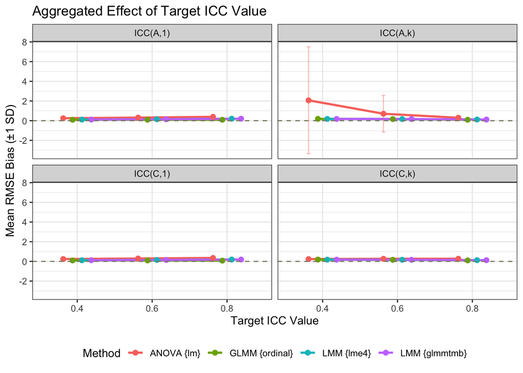

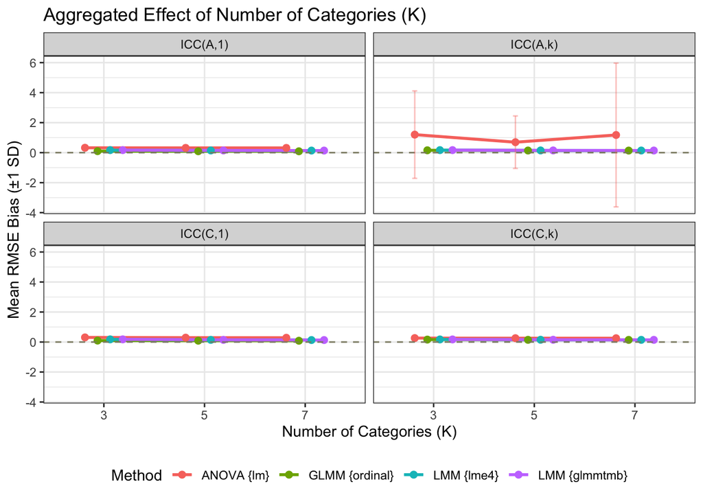

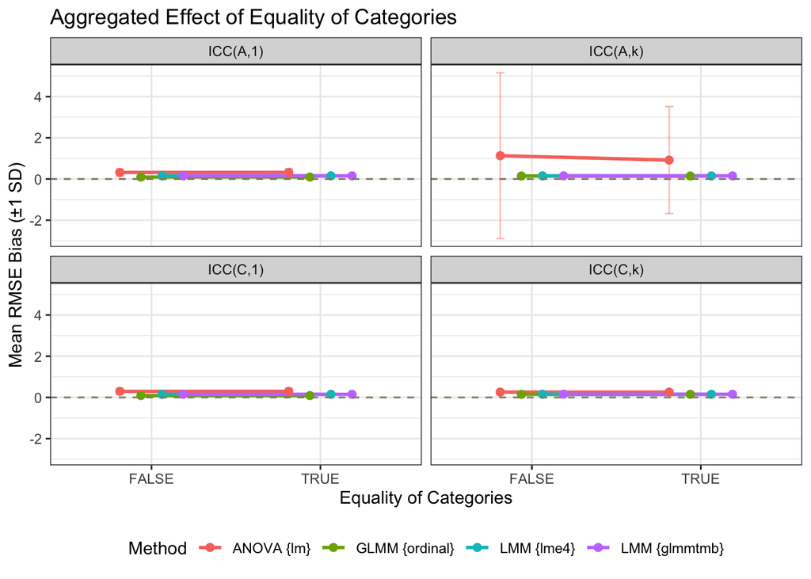

```r
 factors_to_test <- c("n_raters", "n_objects", "target_icc", "k_category", "e_category")

# # Generate a list of faceted plots
 rmse_aggregate_plots <- map(set_names(factors_to_test),
 ~ {plot_aggregated_facet(bias, .x, rmse, 3)
 })

 rmse_aggregate_plots
```

# 3. Performance Measures for Standard Errors

- Standard Errors (i.e., standard deviation of replication distribution)

“A first order question is whether our estimated standard errors are calibrated, meaning whether they are the right size, on average. For this question we will examine the bias of squared standard error estimators. A second order question is whether our estimated standard errors are stable, meaning that they do not vary too much from one dataset to another. For this question we evaluate estimated standard errors in terms of effective degrees of freedom or the standard error (or RMSE) of the standard error.”

## 3.1 Calibration

relative bias (calibration) of v = V_bar (the average variance of across replications, of the variance/SE for each replication utilizing a variance estimator of ICC ) / standard devaition( of T across all replications!)